# 605 HW 5

simplymathematics

September 30, 2018

```r
B <- runif(1)
C <- runif(1)

B
```

```
## [1] 0.4267966
```

```r
C
```

```
## [1] 0.07936053
```

```r
help(runif)
```

Additionally, we must show that $f(x) \geq 0$, which is true by inspection. Another condition is that $\int_{a}^{b} f(x) = 1$ on the interval specified. The help(runif) command (or other documentation) gives us our f(x) such that
$$f(x) = \frac{1}{max-min}= \frac{1}{1-0} = 1$$
or
$$\int_{a}^{b}1\space dx = b - a = 1-0 = 1$$
## B + C < 1/2

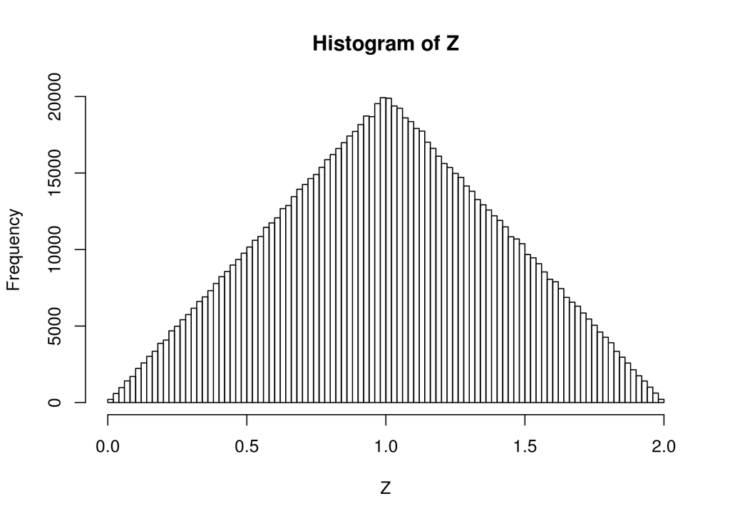

```r
B <- runif(1000000)
C <- runif(1000000)
Z <- B+C
hist(Z, breaks=100)
```

Since we know that these variables are independent, their sum can be modelled as standard, symmetrical triangular distribution with peak = 1. Therefore
$$P(B+C<\frac{1}{2})$$

$$P(x) \begin{cases}
\frac{2(x-a)}{(b-a)(b-c)} & \text{for } a < x < c \\
\frac{2(b-x)}{(b-a)(b-c)} & \text{for } c < x < b
\end{cases}$$

where (if a = 0, b =2, and c = midpont(a,b)

$$P(x) \begin{cases}
\frac{2(x-0)}{(2-0)(2-1)} & \text{for } a < x < c \\
\frac{2(b-x)}{(2-0)(2-1)} & \text{for } c < x < b
\end{cases}$$

or

$$P(x) \begin{cases}
\frac{2x}{2} & \text{for } a < x < c \\
\frac{4-2x}{2} & \text{for } c < x < b
\end{cases}$$
or
$$P(x) \begin{cases}
x & \text{for } a < x < c \\
2-x & \text{for } c < x < b
\end{cases}$$
and the cumulative distribution function for the piece [c,b]
$$D(x) = \frac{(x-a)^2}{(b-a)(c-a)} = \frac{\frac{1}{2}^2-0^2}{(2-0)(2-1)} = \frac{1}{8}$$
where x is B + C. ## BC < 1/2

The cumulative distribution function is

$$F(x)= \begin{cases}
0 & \text{for }x < a \\[8pt]
\frac{x-a}{b-a} & \text{for }a \le x \le b \\[8pt]
1 & \text{for }x > b
\end{cases}$$
Therefore, the
$$P(x<\frac{1}{2}) = \int_{0}^{1} \frac{x-a}{b-a} dx = \int_{0}^{1} \frac{1/2-0}{1-0}dx = \int_{0}^{1}\frac{1}{2} dx = 1/2$$
Since this is true for both B and C, we can multiply this final number to obtain
$$\frac{1}{2} \cdot \frac{1}{2} = \frac {1}{4}$$

## |B-C|<1/2

If $Z= B-C$ then $W = Z + 1$ has the form $W = X + (1-Y) = X + Y’ where X and Y’ = 1-Y are independent, random variables on [0,1], which has a well known triangular density such that
$$F_y(Y) = P(Y\le y) = P(B-C < y) =
\begin{cases}
\int_0^{1+y}\int_{x_1-y}^11dx_2dx_1 & -1 <y < 0 \\
1 - \int_y^1\int_0^{x_1-y}1dx_2dx_1 & 0<y<1
\end{cases}$$
or

The cumulative distribution function for one variable is

$$F(x)= \begin{cases}
0 & \text{for }x < a \\[8pt]
\frac{x-a}{b-a} & \text{for }a \le x \le b \\[8pt]
1 & \text{for }x > b
\end{cases}$$
Therefore, the
$$P(x<\frac{1}{2}) = \int_{0}^{1} \frac{x-a}{b-a} dx = \int_{0}^{1} \frac{1/2-0}{1-0}dx = \int_{0}^{1}\frac{1}{2} dx =\frac{1}{2}$$
Since this is true for both B and C, we can multiply this final number to obtain
$$\frac{1}{2} \cdot \frac{1}{2} = \frac {1}{4}$$

## min{B,C} <1/2

This is logically equivalent to
$$P(B < \frac{1}{2} \cup C < \frac{1}{2})$$
or
$$P(B < \frac{1}{2}) + P(C < \frac{1}{2}) - P(B\cap C) = \frac{1}{2} + \frac{1}{2} - \frac{1}{4} = \frac{3}{4}$$